# Hands-on Exercise 5a: Creating Ternary Plot with R

Author

Andy Tai

Published

May 9, 2026

Modified

May 9, 2026

## 1 Overview

Ternary plots are graphical tools used to visualise the distribution and variation of compositional data made up of three components. Examples include the proportions of young, economically active, and elderly populations, or the composition of sand, silt, and clay in soil samples. The plot is represented as a triangle scaled from 0 to 1 along each side, where each side corresponds to one of the three components. A data point is positioned such that its perpendicular distance to each side reflects the value of the respective component.

In this hands-on exercise, we will learn how to create ternary plots programmatically in R to analyse and visualise the population structure of Singapore.

The exercise is organised into four main steps:

1. Install and load the **tidyverse** and **ggtern** packages.
2. Create three new measures using the `mutate()` function from the **dplyr** package.
3. Construct a static ternary plot using the `ggtern()` function from the **ggtern** package.
4. Create an interactive ternary plot using the `plot_ly()` function from the **Plotly R** package.

## 2 Getting Started

**Installing & Launching R Packages**

```r
pacman::p_load(plotly, tidyverse, ggtern, tricolore, gganimate)
```

**Importing Data**

The original data is obtained from Singapore Residents by Planning AreaSubzone, Age Group, Sex and Type of Dwelling, June 2000-2025 off the [Singstat](https://www.singstat.gov.sg/) website.

```r
#Reading the data into R environment
pop_data <- read_csv("data/respopagesextod2025.csv")
```

**Preparing Data**

The code chunk below performs several tasks:

```r
agpop_mutated <- pop_data %>%
  filter(Sex == "Males") %>%
  spread(AG, Pop) %>%
  mutate(
    YOUNG  = rowSums(select(., `0_to_4`, `5_to_9`, `10_to_14`, `15_to_19`, `20_to_24`), na.rm = TRUE),
    ACTIVE = rowSums(select(., `25_to_29`, `30_to_34`, `35_to_39`, `40_to_44`, `45_to_49`,`50_to_54`, `55_to_59`, `60_to_64`), na.rm = TRUE),
    OLD    = rowSums(select(., `65_to_69`, `70_to_74`, `75_to_79`, `80_to_84`,
                               `85_to_89`, `90_and_over`), na.rm = TRUE),
    TOTAL  = YOUNG + ACTIVE + OLD
  ) %>%
  filter(Time == 2025) %>%
  filter(TOTAL > 0)

head(agpop_mutated)
```

```
# A tibble: 6 × 28
  PA         SZ      Sex   TOD    Time `0_to_4` `10_to_14` `15_to_19` `20_to_24`
  <chr>      <chr>   <chr> <chr> <dbl>    <dbl>      <dbl>      <dbl>      <dbl>
1 Ang Mo Kio Ang Mo… Males Cond…  2025       30         80         70         80
2 Ang Mo Kio Ang Mo… Males HDB …  2025        0         10         10          0
3 Ang Mo Kio Ang Mo… Males HDB …  2025       10         10         10         20
4 Ang Mo Kio Ang Mo… Males HDB …  2025       10         50         50         40
5 Ang Mo Kio Cheng … Males HDB …  2025       20         20         10         30
6 Ang Mo Kio Cheng … Males HDB …  2025      120        170        210        260
# ℹ 19 more variables: `25_to_29` <dbl>, `30_to_34` <dbl>, `35_to_39` <dbl>,
#   `40_to_44` <dbl>, `45_to_49` <dbl>, `5_to_9` <dbl>, `50_to_54` <dbl>,
#   `55_to_59` <dbl>, `60_to_64` <dbl>, `65_to_69` <dbl>, `70_to_74` <dbl>,
#   `75_to_79` <dbl>, `80_to_84` <dbl>, `85_to_89` <dbl>, `90_and_over` <dbl>,
#   YOUNG <dbl>, ACTIVE <dbl>, OLD <dbl>, TOTAL <dbl>
```

## 3 Plotting Ternary Diagram with R

**(a) Basic Plot**

Here, we use `ggtern()` function of **ggtern** package to create a simple ternary plot. We also style it with color and title.

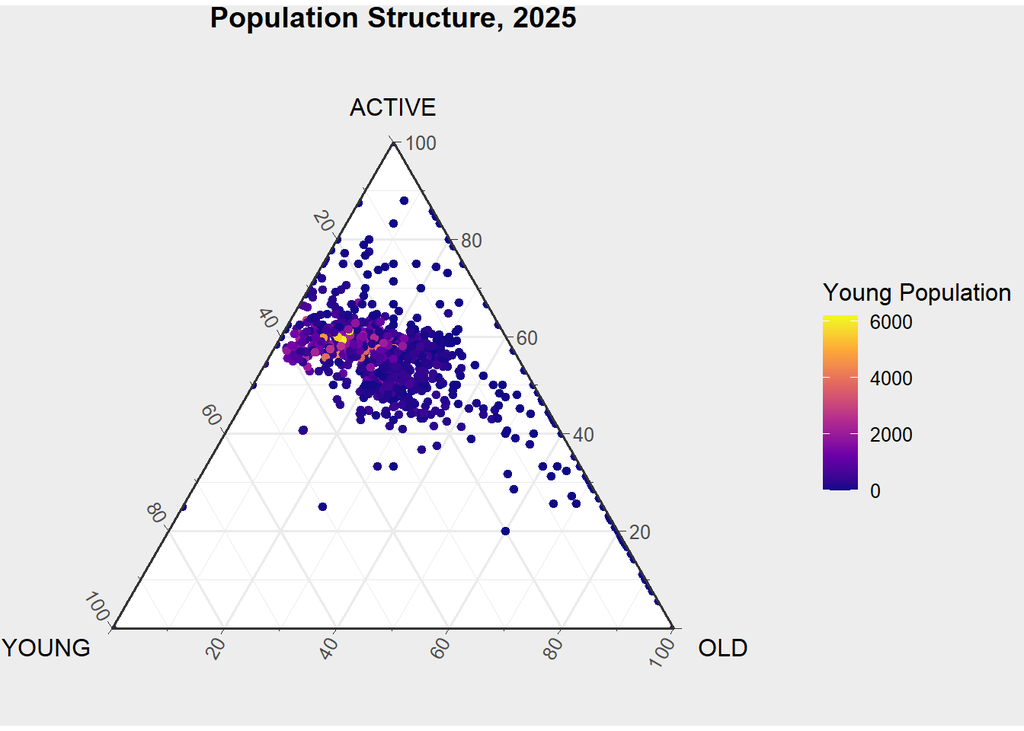

```r
ggtern(data = agpop_mutated,
       aes(x = YOUNG, y = ACTIVE, z = OLD, colour = YOUNG)) +
  geom_point() +
  scale_colour_viridis_c(option = "plasma", name = "Young Population") +
  labs(title = "Population Structure, 2025") +
  theme_bw() +
  theme(
    plot.title = element_text(hjust = 0.5, face = "bold"),
    legend.background = element_rect(colour = "grey93", fill = "grey93"),
    plot.background = element_rect(fill = "grey93", colour = "grey93")
  )
```

**(b) Subplots + tricolore**

The following code filter the data for male and female.

```r
library(tricolore)
library(cowplot)

agpop_male <- pop_data %>%
  filter(Sex == "Males") %>%
  spread(AG, Pop) %>%
  mutate(
    YOUNG  = rowSums(select(., `0_to_4`, `5_to_9`, `10_to_14`, `15_to_19`, `20_to_24`), na.rm = TRUE),
    ACTIVE = rowSums(select(., `25_to_29`, `30_to_34`, `35_to_39`, `40_to_44`, `45_to_49`, `50_to_54`, `55_to_59`, `60_to_64`), na.rm = TRUE),
    OLD    = rowSums(select(., `65_to_69`, `70_to_74`, `75_to_79`, `80_to_84`,
                               `85_to_89`, `90_and_over`), na.rm = TRUE),
    TOTAL  = YOUNG + ACTIVE + OLD
  ) %>%
  filter(Time == 2025, TOTAL > 0)

agpop_male$tc_color <- Tricolore(agpop_male, p1 = "YOUNG", p2 = "ACTIVE", p3 = "OLD")$color

agpop_female <- pop_data %>%
  filter(Sex == "Females") %>%
  spread(AG, Pop) %>%
  mutate(
    YOUNG  = rowSums(select(., `0_to_4`, `5_to_9`, `10_to_14`, `15_to_19`, `20_to_24`), na.rm = TRUE),
    ACTIVE = rowSums(select(., `25_to_29`, `30_to_34`, `35_to_39`, `40_to_44`, `45_to_49`, `50_to_54`, `55_to_59`, `60_to_64`), na.rm = TRUE),
    OLD    = rowSums(select(., `65_to_69`, `70_to_74`, `75_to_79`, `80_to_84`,
                               `85_to_89`, `90_and_over`), na.rm = TRUE),
    TOTAL  = YOUNG + ACTIVE + OLD
  ) %>%
  filter(Time == 2025, TOTAL > 0)

agpop_female$tc_color <- Tricolore(agpop_female, p1 = "YOUNG", p2 = "ACTIVE", p3 = "OLD")$color
```

Normalise proportions and regenerate Tricolore colors

```r
agpop_male <- agpop_male %>%
  mutate(
    YOUNG_P  = YOUNG / TOTAL,
    ACTIVE_P = ACTIVE / TOTAL,
    OLD_P    = OLD / TOTAL
  )

agpop_female <- agpop_female %>%
  mutate(
    YOUNG_P  = YOUNG / TOTAL,
    ACTIVE_P = ACTIVE / TOTAL,
    OLD_P    = OLD / TOTAL
  )

agpop_male$tc_color   <- Tricolore(agpop_male,   p1 = "YOUNG_P", p2 = "ACTIVE_P", p3 = "OLD_P")$rgb
agpop_female$tc_color <- Tricolore(agpop_female, p1 = "YOUNG_P", p2 = "ACTIVE_P", p3 = "OLD_P")$rgb
```

Next, we create the ternary diagrams for male and female side-by-side using `layout-ncol=2`

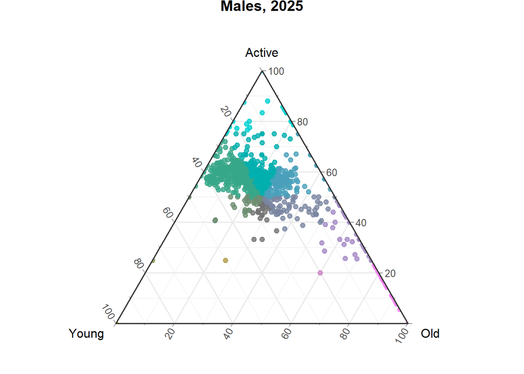

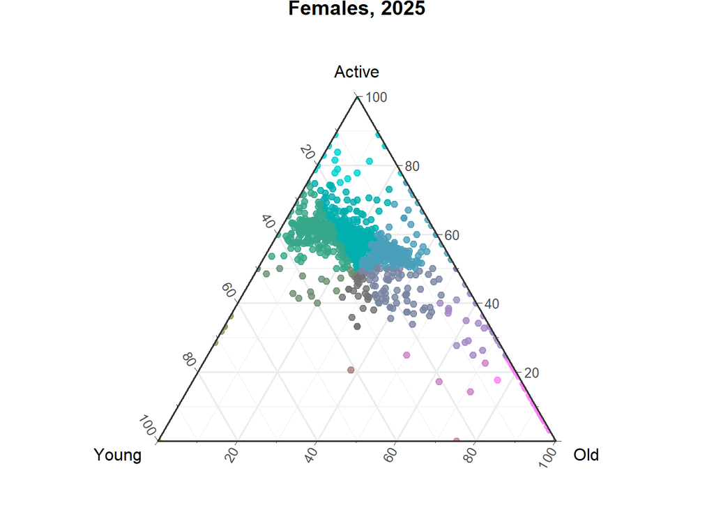

```r
male_colors <- agpop_male$tc_color   #<< extract first

ggtern(data = agpop_male,
       aes(x = YOUNG, y = ACTIVE, z = OLD)) +
  geom_point(color = male_colors,    #<< plain vector
             size = 2, alpha = 0.8) +
  labs(title = "Males, 2025", x = "Young", y = "Active", z = "Old") +
  theme_bw() +
  theme(plot.title = element_text(hjust = 0.5, face = "bold"))
female_colors <- agpop_female$tc_color  #<< extract first

ggtern(data = agpop_female,
       aes(x = YOUNG, y = ACTIVE, z = OLD)) +
  geom_point(color = female_colors,     #<< plain vector
             size = 2, alpha = 0.8) +
  labs(title = "Females, 2025", x = "Young", y = "Active", z = "Old") +
  theme_bw() +
  theme(plot.title = element_text(hjust = 0.5, face = "bold"))
```

**(c) Interactive**

```r
paxis <- function(txt) {
  list(
    title = txt,
    tickformat = ".0%",
    tickfont = list(size = 10),
    titlefont = list(size = 12),
    gridcolor = "lightgrey",
    linecolor = "black",
    linewidth = 1
  )
}

ternaryAxes <- list(
  aaxis = paxis("Young"),
  baxis = paxis("Economically Active"),
  caxis = paxis("Aged")
)

plot_ly() %>%
  add_trace(
    data = agpop_male,
    a = ~YOUNG_P, b = ~ACTIVE_P, c = ~OLD_P,
    color = I("steelblue"),
    type = "scatterternary",
    mode = "markers",
    marker = list(size = 6, opacity = 0.7),
    text = ~paste("PA:", PA, "<br>SZ:", SZ),
    hoverinfo = "text",
    subplot = "ternary"
  ) %>%
  add_trace(
    data = agpop_female,
    a = ~YOUNG_P, b = ~ACTIVE_P, c = ~OLD_P,
    color = I("tomato"),
    type = "scatterternary",
    mode = "markers",
    marker = list(size = 6, opacity = 0.7),
    text = ~paste("PA:", PA, "<br>SZ:", SZ),
    hoverinfo = "text",
    subplot = "ternary2"
  ) %>%
  layout(
    title = list(
      text = "Population Structure by Gender, 2025",
      font = list(size = 14, family = "Arial")
    ),

    ## ----- ADJUST THE GAP BETWEEN THE 2 TRIANGLES ---
ternary  = c(ternaryAxes, list(domain = list(x = c(0.05, 0.42), y = c(0, 0.9)))),
ternary2 = c(ternaryAxes, list(domain = list(x = c(0.62, 0.97), y = c(0, 0.9)))),

    ## ----------
annotations = list(list(text = "Males, 2025",   x = 0.15, y = 0.98, xref = "paper", yref = "paper", showarrow = FALSE, font = list(size = 13),
bgcolor = "white", bordercolor = "black", borderwidth = 1.5),
list(text = "Females, 2025", x = 0.82, y = 0.98, xref = "paper", yref = "paper",
showarrow = FALSE, font = list(size = 13),
bgcolor = "white", bordercolor = "black", borderwidth = 1.5)),
paper_bgcolor = "white",
showlegend = FALSE,
margin = list(t = 80, r = 100, l = 80, b = 60)  #<< right margin to prevent truncation
  )
```

[interactive chart not shown]

**(d) gganimate**

```r
agpop_animated <- pop_data %>%
  spread(AG, Pop) %>%                                    #<< spread first
  mutate(across(`0_to_4`:`90_and_over`, ~replace_na(., 0))) %>%
  group_by(PA, SZ, TOD, Time) %>%
  summarise(
    across(`0_to_4`:`90_and_over`, sum),                 #<< then sum by group
    .groups = "drop"
  ) %>%
  mutate(
    YOUNG  = rowSums(select(., `0_to_4`, `5_to_9`, `10_to_14`, `15_to_19`, `20_to_24`), na.rm = TRUE),
    ACTIVE = rowSums(select(., `25_to_29`, `30_to_34`, `35_to_39`, `40_to_44`, `45_to_49`,`50_to_54`, `55_to_59`, `60_to_64`), na.rm = TRUE),
    OLD    = rowSums(select(., `65_to_69`, `70_to_74`, `75_to_79`, `80_to_84`,
`85_to_89`, `90_and_over`), na.rm = TRUE),
    TOTAL  = YOUNG + ACTIVE + OLD
  ) %>%
  filter(Time == 2025, TOTAL > 0)
```

Next we animate the plot

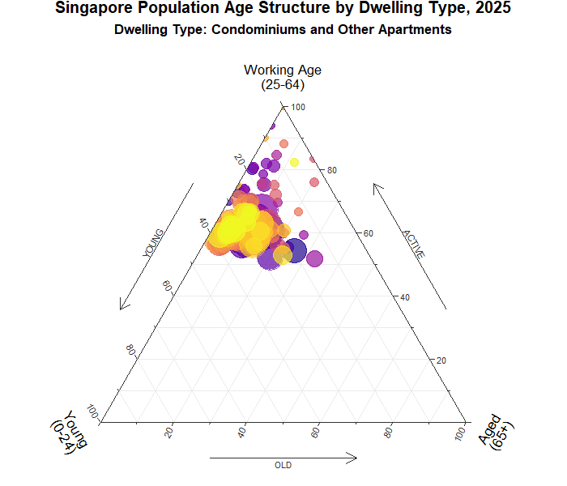

```r
library(magick)

tod_list <- unique(agpop_animated$TOD)

frames <- lapply(tod_list, function(tod) {
  df <- agpop_animated %>% filter(TOD == tod)

  p <- ggtern(data = df,
              aes(x = YOUNG, y = ACTIVE, z = OLD,
                  size = TOTAL, color = PA)) +
    geom_point(alpha = 0.7, show.legend = FALSE) +
    scale_color_viridis_d(option = "plasma") +
    scale_size(range = c(2, 15)) +
    scale_L_continuous("Young\n(0-24)") +
    scale_T_continuous("Working Age\n(25-64)") +
    scale_R_continuous("Aged\n(65+)") +
    labs(
      title = "Singapore Population Age Structure by Dwelling Type, 2025",
      subtitle = paste("Dwelling Type:", tod)
    ) +
    theme_bw() +
    theme(
      tern.axis.arrow.show = TRUE,
      tern.axis.text    = element_text(size = 8, colour = "grey20"),
      tern.axis.title.L = element_text(hjust = 0.2, vjust = 0.7, angle = -60),
      tern.axis.title.R = element_text(hjust = 0.8, vjust = 0.6, angle = 60),
      plot.title    = element_text(hjust = 0.5, face = "bold"),
      plot.subtitle = element_text(hjust = 0.5, face = "bold"),
      legend.position = "none"
    )

  tmp <- tempfile(fileext = ".png")
  ggsave(tmp, p, width = 7, height = 6, dpi = 100)
  image_read(tmp)
})

animation <- image_join(frames)
image_animate(animation, fps = 1)
```

**(e) Animated**

Lastly, here’s the chart using plotly animation.

```r
td3 <- plot_ly(agpop_animated,
               a = ~ACTIVE,
               b = ~YOUNG,
               c = ~OLD,
               frame = ~TOD,
               mode = "markers",
               size = ~TOTAL,
               color = ~PA,
               type = "scatterternary",
               text = ~paste("Young:", YOUNG,
                             "<br>Economically Active:", ACTIVE,
                             "<br>Aged:", OLD,
                             "<br>Subzone:", SZ,
                             "<br>Planning Area:", PA),
               hoverinfo = "text",
               marker = list(
                 symbol = "circle",
                 opacity = 0.8,
                 sizemode = "diameter",
                 sizeref = 2,
                 line = list(width = 2, color = "#FFFFFF")
               )) %>%
  layout(
    title = list(
      text = "Demographic Composition of Singapore by Dwelling Type, 2025",
      font = list(size = 14, family = "Arial"),
      x = 0.5,
      y = 0.98                                      #<< push title up
    ),
    ternary = list(
      aaxis = list(title = "Economically Active",
                   tickformat = ".0%",
                   gridcolor = "lightgrey",
                   linecolor = "black"),
      baxis = list(title = "Young",
                   tickformat = ".0%",
                   gridcolor = "lightgrey",
                   linecolor = "black"),
      caxis = list(title = "Aged",
                   tickformat = ".0%",
                   gridcolor = "lightgrey",
                   linecolor = "black"),
      domain = list(x = c(0, 1), y = c(0, 0.88))   #<< shrink ternary down
    ),
    paper_bgcolor = "white",
    plot_bgcolor  = "white",
    margin = list(t = 80)                           #<< top margin
  )

td3
```

[interactive chart not shown]

## 4 References

- Kam, T.S. (2023). [Creating Ternary Plot with R](https://r4va.netlify.app/chap13).